# Taller avanzado de R

31 de marzo de 2016

## Introducción

## Repositorio

- Página: `https://github.com/nanounanue/xxvii-congreso-nacional-actuaria-udla/tree/master`
- Repo: `git@github.com:nanounanue/xxvii-congreso-nacional-actuaria-udla.git`
- [Descargar `zip`](https://github.com/nanounanue/xxvii-congreso-nacional-actuaria-udla/archive/master.zip)

## Instalamos los paquetes

```r
instalar <- function(paquete) {

    if (!require(paquete,character.only = TRUE, quietly = TRUE, warn.conflicts = FALSE)) {
        install.packages(as.character(paquete), dependecies = TRUE, repos = "http://cran.us.r-project.org")
        library(paquete, character.only = TRUE, quietly = TRUE, warn.conflicts = FALSE)
    }
}

paquetes <- c('lubridate', 'magrittr', 'ggvis', 'dplyr', 'tidyr', 'readr', 'rvest',
              'ggplot2', 'stringr', 'babynames', 'ggthemes', 'googleVis', 'shiny')

lapply(paquetes, instalar)

options(digits = 3)
```

## Ciencia de datos

## Actividades de la ciencia de datos

1. Leer un conjunto de datos
2. Limpiarlo
3. Manipularlo
4. Explorarlo
5. Guardarlo
6. Modelarlo
7. Comunicarlo
8. Productificarlo

## Pipelines

## `%>%`

Por que anidar, si podemos platicar

```r
# Normalmente
mas <- function(x, y) x + y
por <- function(x, y) x * y

# 2 * 10 + 1
# Dos por 10 mas 1
mas(1, por(2, 10))
```

```
## [1] 21
```

```r
x %>% f(y) -> f(x, y)
x %>% f(y) %>% g(z) -> g(f(x, y), z)
```

```r
# Dos por 10 mas 1
2 %>%
  por(10) %>%
  mas(1)
```

```
## [1] 21
```

## Dataset

- Vamos a utilizar un conjunto de datos (*data set*) que describe los accidentes en trenes en 2015.
- Lo obtuve de esta página [FRA Office of Safety Analysis Web Site](http://safetydata.fra.dot.gov/officeofsafety/default.aspx)
  - En el menú de `Downloads` y seleccioné **Accident Data as reported by Railroads**.
  - Elegí los parámetros por default, y pedí que la descarga fuera en formato `TXT` (en realidad es un `csv`).
- Ya se encuentra en la carpeta `data`.
- El significado de cada columna se puede ver en el archivo `accfile_ThruMay2011.pdf` en la carpeta del proyecto.

## Columnas interesantes

Nos quedaremos con las siguientes columnas

| Nombre de columna | Número de columna | Variable |
| --- | --- | --- |
| YEAR | 16 | year of incident |
| MONTH | 17 | month of incident |
| DAY | 18 | day of incident |
| TIMEHR | 19 | hour of incident |
| TIMEMIN | 20 | minutes of incident |
| AMPM | 21 | ampm |
| TYPE | 22 | type of accident |
| CARS | 23 | cars hazmat |
| CARSDMG | 24 | cars hazmat damaged |

## Columnas interesantes (cont)

| Nombre de columna | Número de columna | Variable |
| --- | --- | --- |
| CARSHZD | 25 | cars hazmat realeased |
| EVACUATE | 26 | persons evacuated |
| STATION | 28 | nearest city |
| STATE | 30 | state (FIPS) |
| TEMP | 31 | temperature |
| VISIBLTY | 32 | visibility |
| WEATHER | 33 | weather |
| TRNSPD | 34 | train speed |
| TYPSPD | 35 | train speed type |
| TRNDIR | 37 | train direction |

## Columnas interesantes (cont)

| Nombre de columna | Número de columna | Variable |
| --- | --- | --- |
| TONS | 38 | tonnage |
| TYPEQ | 39 | train type |
| RRCAR1 | 45 | car initials 1 |
| CARNBR1 | 46 | car number 1 |
| POSITON1 | 47 | car position in train 1 |
| LOADED1 | 48 | car loaded or not 1 |
| RRCAR2 | 49 | car initials 2 |
| CARNBR2 | 50 | car number 2 |
| POSITON2 | 51 | car position in train 1 |
| LOADED2 | 52 | car loaded or not 1 |

## Columnas interesantes (cont)

| Nombre de columna | Número de columna | Variable |
| --- | --- | --- |
| CAUSE | 75 | primary cause |
| CAUSE2 | 76 | secondary cause |
| CASKLD | 79 | killed |
| CASINJ | 80 | injured |
| ACCDMG | 85 | total damage ($) |
| CNTYCD | 115 | county (FIPS) |
| ALCOHOL | 117 | positive alcohol tests |
| DRUG | 118 | positive drug tests |
| Latitude | 139 | lat |
| Longitud | 140 | long |

## Leer

El primer paso es *cargar* el data set a `R`

```r
(accidents.df <- read_csv(file="data/1417426.txt")) ## Estamos usando el paquete readr
```

```
## Source: local data frame [1,011 x 146]
##
##    AMTRAK   IYR   IMO RAILROAD   INCDTNO  IYR2  IMO2   RR2 INCDTNO2  IYR3
##     (chr) (int) (chr)    (chr)     (chr) (int) (chr) (chr)    (chr) (int)
## 1      NA    15    05       UP 0515KC002    NA    NA                   15
## 2      NA    15    01     CRSH    113847    NA    NA                   15
## 3      NA    15    01     CRSH    113847    NA    NA                   15
## 4      NA    15    05       UP 0515KC010    NA    NA                   15
## 5      NA    15    05       UP 0515PR003    NA    NA                   15
## 6      NA    15    05       UP 0515PR003    NA    NA                   15
## 7      NA    15    05       UP 0515PR030    NA    NA                   15
## 8      NA    15    03      CSX 000143277    NA    NA                   15
## 9      NA    15    01       UP 0115CB003    NA    NA                   15
## 10     NA    15    01     UPME 0115PR016    NA    NA                   15
## ..    ...   ...   ...      ...       ...   ...   ...   ...      ...   ...
## Variables not shown: IMO3 (chr), RR3 (chr), INCDTNO3 (chr), DUMMY1 (chr),
##   GXID (chr), YEAR (int), MONTH (chr), DAY (chr), TIMEHR (dbl), TIMEMIN
##   (dbl), AMPM (chr), TYPE (chr), CARS (dbl), CARSDMG (dbl), CARSHZD (dbl),
##   EVACUATE (dbl), DIVISION (chr), STATION (chr), MILEPOST (chr), STATE
##   (chr), TEMP (dbl), VISIBLTY (int), WEATHER (int), TRNSPD (chr), TYPSPD
##   (chr), TRNNBR (chr), TRNDIR (int), TONS (dbl), TYPEQ (chr), EQATT (chr),
##   TRKNAME (chr), TRKCLAS (chr), TRKDNSTY (chr), TYPTRK (int), RRCAR1
##   (chr), CARNBR1 (chr), POSITON1 (chr), LOADED1 (chr), RRCAR2 (chr),
##   CARNBR2 (chr), POSITON2 (chr), LOADED2 (chr), HEADEND1 (dbl), MIDMAN1
##   (dbl), MIDREM1 (dbl), RMAN1 (dbl), RREM1 (dbl), HEADEND2 (dbl), MIDMAN2
##   (dbl), MIDREM2 (dbl), RMAN2 (dbl), RREM2 (dbl), LOADF1 (dbl), LOADP1
##   (dbl), EMPTYF1 (dbl), EMPTYP1 (dbl), CABOOSE1 (dbl), LOADF2 (dbl),
##   LOADP2 (dbl), EMPTYF2 (dbl), EMPTYP2 (dbl), CABOOSE2 (dbl), EQPDMG
##   (dbl), TRKDMG (dbl), CAUSE (chr), CAUSE2 (chr), CASKLDRR (dbl), CASINJRR
##   (dbl), CASKLD (dbl), CASINJ (dbl), ACCAUSE (chr), ACCTRK (int), ACCTRKCL
##   (chr), HIGHSPD (chr), ACCDMG (dbl), DUMMY2 (chr), STCNTY (chr), TOTINJ
##   (dbl), DUMMY3 (chr), TOTKLD (dbl), ENGRS (int), FIREMEN (int), CONDUCTR
##   (int), BRAKEMEN (int), ENGHR (chr), ENGMIN (chr), CDTRHR (chr), CDTRMIN
##   (chr), JOINTCD (int), REGION (int), DUMMY4 (chr), TYPRR (dbl), DUMMY5
##   (chr), RRDIV (chr), METHOD (chr), NARRLEN (dbl), DUMMY6 (chr), YEAR4
##   (int), RREMPKLD (dbl), RREMPINJ (dbl), PASSKLD (dbl), PASSINJ (dbl),
##   OTHERKLD (dbl), OTHERINJ (dbl), COUNTY (chr), CNTYCD (chr), ALCOHOL
##   (chr), DRUG (chr), DUMMY7 (chr), PASSTRN (chr), SSB1 (chr), SSB2 (chr),
##   NARR1 (chr), NARR2 (chr), NARR3 (chr), NARR4 (chr), NARR5 (chr), NARR6
##   (chr), NARR7 (chr), NARR8 (chr), NARR9 (chr), NARR10 (chr), NARR11
##   (chr), NARR12 (chr), NARR13 (chr), NARR14 (chr), NARR15 (chr), RCL
##   (int), Latitude (dbl), Longitud (dbl), SIGNAL (int), MOPERA (int),
##   ADJUNCT1 (chr), ADJUNCT2 (chr), ADJUNCT3 (chr), SUBDIV (chr)
```

## Ejercicio

- ¿Cuántos accidentes están reportados?
- ¿Cuántas variables tiene el data set?

## Leer

La estructura del data set se puede obtener con `glimpse`

```r
glimpse(accidents.df)
```

```
## Observations: 1,011
## Variables: 146
## $ AMTRAK   (chr) NA, NA, NA, NA, NA, NA, NA, NA, NA, NA, NA, NA, NA, N...
## $ IYR      (int) 15, 15, 15, 15, 15, 15, 15, 15, 15, 15, 15, 15, 15, 1...
## $ IMO      (chr) "05", "01", "01", "05", "05", "05", "05", "03", "01",...
## $ RAILROAD (chr) "UP", "CRSH", "CRSH", "UP", "UP", "UP", "UP", "CSX", ...
## $ INCDTNO  (chr) "0515KC002", "113847", "113847", "0515KC010", "0515PR...
## $ IYR2     (int) NA, NA, NA, NA, NA, NA, NA, NA, NA, NA, NA, NA, NA, N...
## $ IMO2     (chr) NA, NA, NA, NA, NA, NA, NA, NA, NA, NA, NA, NA, NA, N...
## $ RR2      (chr) "", "", "", "", "", "", "", "", "", "", "", "", "", "...
## $ INCDTNO2 (chr) "", "", "", "", "", "", "", "", "", "", "", "", "", "...
## $ IYR3     (int) 15, 15, 15, 15, 15, 15, 15, 15, 15, 15, 15, 15, 15, 1...
## $ IMO3     (chr) "05", "01", "01", "05", "05", "05", "05", "03", "01",...
## $ RR3      (chr) "UP", "CRSH", "CRSH", "UP", "UP", "UP", "UP", "CSX", ...
## $ INCDTNO3 (chr) "0515KC002", "113847", "113847", "0515KC010", "0515PR...
```

[output cut: 133 more lines]

## Leer

- `R` también puede leer datos desde la web, scrapear, usar bases de datos, leer archivos de Excel, etc.
- Algo de esto usaremos en los casos de estudio

## Limpieza

## Manipular

- Como puedes observar, los datos (cuando existen), regularmente son una porqueria. Es necesario **manipularlos**: Limpiarlos y acomodarlos para que puedan servir al análisis.
- Para esto utilizaremos dos *bibliotecas* de funciones: `dplyr` y `tidyr`.
- Siempre es útil tener a la mano [esto](https://docs.google.com/viewer?url=https%3A%2F%2Fwww.rstudio.com%2Fwp-content%2Fuploads%2F2015%2F02%2Fdata-wrangling-cheatsheet.pdf).

## Manipular

- `dplyr` maneja 5 verbos para la manipulación de los datos.
  - `filter`
  - `select`
  - `mutate`
  - `arrange`
  - `summarize`

Además `dplyr` popularizó el operador de *entubamiento* : `%>%`.

## Manipular

Nuestro plan de batalla será el siguiente:

1. Quitar las columnas que no nos parecen interesantes.
2. Ajustar el *tipo* de las columnas para su mejor representación.
3. Crear y/o limpiar columnas

## Manipular

```r
accidents <- accidents.df %>%
    select(YEAR:EVACUATE, STATION, STATE:TYPSPD, TRNDIR:TYPEQ,
           RRCAR1:LOADED2, CAUSE, CAUSE2, CASKLD, CASINJ,
           ACCDMG, CNTYCD, ALCOHOL, DRUG, Latitude, Longitud)
```

## Ejercicio

- Renombra las columnas para que tengan sentido:
- Todo a minúsculas
- `car_initials_1=RRCAR1, car_number_1=CARNBR1, car_initials_2=RRCAR2, car_number_2=CARNBR2,` `accident_type=TYPE, cars_hazmat=CARS, cars_hazmat_damaged=CARSDMG, cars_hazmat_realeased=CARSHZD,` `persons_evacuated=EVACUATE, nearest_city=STATION, state=STATE, temperature=TEMP, visibility=VISIBLTY,` `weather=WEATHER, train_speed=TRNSPD, train_speed_type=TYPSPD, train_direction=TRNDIR, tonnage=TONS,` `train_type=TYPEQ, primary_cause=CAUSE, secondary_cause=CAUSE2, killed=CASKLD, injured=CASINJ, lat=Latitude, long=Longitud` `car_position_1=POSITON1, car_loaded_1=LOADED1, car_position_2=POSITON2, car_loaded_2=LOADED2, total_damage=ACCDMG,` `county=CNTYCD, alcohol=ALCOHOL, drugs=DRUG`

## Manipular

Muchas variables son categóricas, pero nuestro *data set* las tiene como caracteres. Arreglémos eso.

```r
accidents <- accidents %>%
  mutate(car_id_1 = paste(car_initials_1, car_number_1, sep="-"),
         car_id_2 = paste(car_initials_2, car_number_2, sep="-"),
         hour = ifelse(ampm=='AM', hour, hour+12),
         timestamp = ymd_hm(paste(year,month,day,str_pad(hour, 2, 'left', '0'), str_pad(minutes, 2, 'left', '0'))),
         year = year(timestamp), month=month(timestamp, label=TRUE, abbr=TRUE),
         day=day(timestamp), wday=wday(timestamp, label=TRUE, abbr=TRUE), hour=hour(timestamp), minutes=minute(timestamp)) %>%
         mutate_each(funs(as.factor), c(ampm, nearest_city, state, car_id_1, car_id_2, accident_type))
```

- Ejercicio: ¿Qué otras variables son categóricas? Modifica el código para que así lo sea.
- Ejercicio: Usa el pdf y agrega etiquetas a las variables categóricas
- Ejercicio: ¿Cómo removemos `car.initials.x` y `car.number.x`?
- Ejercicio: La temperatura está en Fahrenheit ¿Cómo la transformarías a Celsius?

## Guardar

Con lo que hemos hecho, es mejor guardar el avance que llevamos. Así, si posteriormente queremos regresar a este estado (si nos equivocamos o algo parecido) podrémos hacerlo.

```r
saveRDS(object = accidents, file="clean/accidents.rds")
```

Esto lo guardará en binario, en un formato específico de `R`.

*Nota que* `R` *también podrá guardar en Excel, csv, bases de datos, etc.*

## Análisis

## Explorar: Estadistica descriptiva

Ahora estamos listos para analizar, el primer paso es limpiar nuestro ambiente (no necesario, pero ampliamente recomendado)

```r
#rm(list=ls())
```

Y luego leer nuestro `data.frame`

```r
accidents <- readRDS("clean/accidents.rds")
```

## Explorar: Estadistica descriptiva

Primero veamos el *data set* completo

```r
# summary(accidents)
```

## Explorar: Estadistica descriptiva

Pero es posible responder preguntas más específicas:

- ¿Cuántos accidentes por estado y por tipo?

```r
accidents %>%
  group_by(state, accident_type) %>%
  summarize(n = n())
```

```
## Source: local data frame [173 x 3]
## Groups: state [?]
##
##     state accident_type     n
##    (fctr)        (fctr) (int)
## 1      01            01    20
## 2      01            04     6
## 3      01            05     3
## 4      01            07     1
## 5      01            12     3
## 6      02            13     1
## 7      04            01     2
## 8      04            07     3
## 9      04            09     1
## 10     04            11     1
## ..    ...           ...   ...
```

## Explorar: Estadistica descriptiva

```r
accidents %>%
  group_by(state) %>%
  summarize(n = n()) %>%
  arrange(desc(n)) %>%
  head()
```

```
## Source: local data frame [6 x 2]
##
##    state     n
##   (fctr) (int)
## 1     48   128
## 2     17   124
## 3     06    52
## 4     18    52
## 5     42    38
## 6     36    36
```

## Explorar: Estadistica descriptiva

- ¿Cuál es el mes con más accidentes? ¿Cuál es la temperatura promedio?

```r
accidents %>%
  group_by(month) %>%
  summarise(n = n(), mean_temperature = mean(temperature))
```

```
## Source: local data frame [5 x 3]
##
##    month     n mean_temperature
##   (fctr) (int)            (dbl)
## 1    Jan   229             1.11
## 2    Feb   189            -1.28
## 3    Mar   244             7.69
## 4    Apr   181            15.11
## 5    May   168            19.76
```

## Explorar: Estadistica descriptiva

**Ejercicio:**

- ¿Cuál es el estado con más muertes?
- ¿Con más heridos?
- ¿La hora con mayor accidentes?

## Exploración visual

Aunque ya vimos el sistema básico de graficación de `R`, ahora veremos dos *bibliotecas* muy potentes:

- `ggplot`
- `ggvis`

Ambas están basadas en algo que se llama **gramática de graficación** y la idea principal es estar agregando capa a capa los elementos de una gráfica (datos, ejes, metadata, etc)

## Explorar: ggplot

Empecemos con algo sencillo: Temperatura por mes

```r
ggplot(data = accidents, aes(x=month, y=temperature)) +
         geom_point(alpha=.4, size=4, color="#880011", position=position_jitter()) +
           labs(x="Mes", y ="Temperatura (°C)", title="Temperatura 2015")
```

## Explorar: ggplot

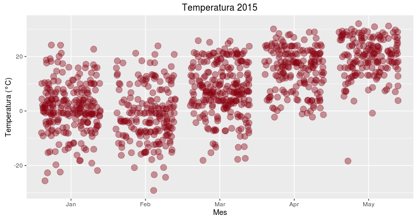

## Explorar: ggplot

Para esta gráfica quizá es mejor mostrar un *boxplot*

```r
ggplot(data = accidents, aes(x=month, y=temperature)) +
         geom_boxplot(outlier.colour = "blue") +
           labs(x="Mes", y ="Temperatura (°C)", title="Temperatura 2015")
```

## Explorar: ggplot

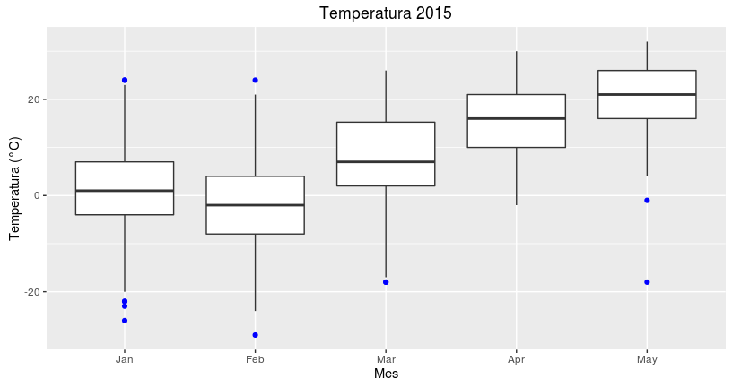

## Explorar: ggplot

Pero extraño los puntos de temperatura…

```r
ggplot(data = accidents, aes(x=month, y=temperature)) +
    geom_boxplot(outlier.colour = "darkred") +
    geom_jitter(alpha=0.3, shape=16, position=position_jitter(0.2), color="#880011") +
    labs(x="Mes", y ="Temperatura (°C)", title ="Temperatura 2015")
```

## Explorar: ggplot

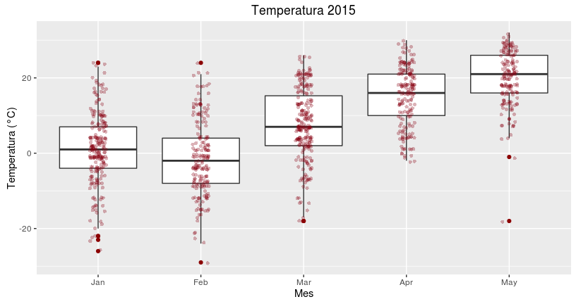

## Explorar: ggplot

Si no nos gusta el *tema* de la gráfica, podemos cambiarlo a uno que más nos guste.

Los diferentes temas se pueden ver [aquí](https://github.com/jrnold/ggthemes).

## Explorar: ggplot

```r
ggplot(data = accidents, aes(x=month, y=temperature)) +
         geom_boxplot(outlier.colour = "darkred") + geom_jitter(alpha=0.3, shape=16, position=position_jitter(0.2), color="#880011") +
           labs(x="Mes", y ="Temperatura (°C)", title = "Temperatura 2015") + theme_hc()
```

## Explorar: ggplot

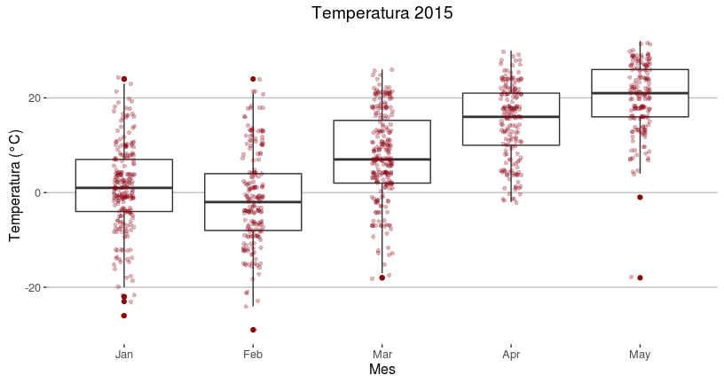

## Explorar: ggplot

```r
ggplot(data = accidents, aes(x=accident_type, y=killed)) +
    geom_boxplot(outlier.colour = "darkred") +
    labs(x="Tipo de Accidente", y ="Decesos", title="Decesos por tipo de accidente") +
    theme_hc()
```

## Explorar: ggplot

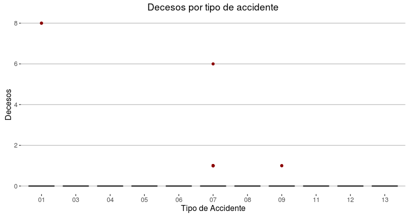

## Explorar: ggplot

Es posible usar `dplyr` con `ggplot`

```r
accidents %>%
    group_by(state) %>%
    summarize(n_obs = n()) %>%
    arrange(desc(n_obs)) %>%
    ggplot(aes(x=state, y = n_obs)) +
    geom_bar(stat="identity") + theme_hc() +
    labs(y="Número de Accidentes", x="Estado", title="Accidentes por Estado")
```

## Explorar: ggplot

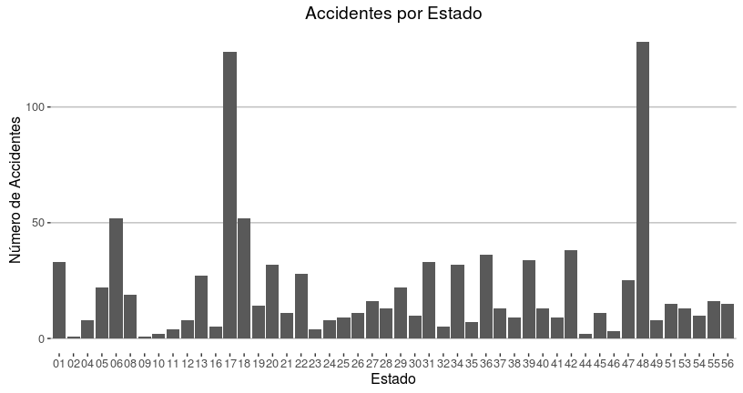

## Explorar: ggplot

**Ejercicio**: ¿Cómo arreglarías la gráfica de *Decesos por tipo de accidente*?

**Ejercicio**: Toma un ejemplo de la sección de análisis exploratorio y grafícalo.

## Explorar: ggplot

Podemos profundizar el análisis, dividiendo por tipo de accidente

```r
accidents %>%
  group_by(state, accident_type) %>% summarize(n_obs = n()) %>%  arrange(desc(n_obs)) %>%
  ggplot(aes(x=state, y = n_obs)) + geom_bar(stat="identity") +
  labs(x="Estados", y="Número de Accidentes", title="Tipos de accidente por estado") +
  facet_wrap(~accident_type)
```

## Explorar: ggplot

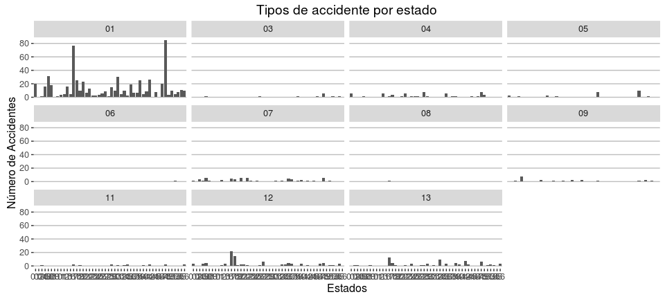

## Explorar: ggvis

- `ggvis` es un paquete nuevo, pero es el futuro de `R` para graficar
- `ggvis` soporta `pipelines` como lo hace `dplyr`y `tidyr`
- Es reactivo (como `shiny`)

## Explorar: ggvis

Observa como es más natural integrar `ggvis` que `ggplot` con el operator `%>%`

```r
accidents %>%
    group_by(state) %>%
    summarize(n_obs = n()) %>%
    arrange(desc(n_obs)) %>%
    ggvis(~state, ~n_obs, fill := 'green') %>%
    layer_bars()
```

[output not shown]

## Explorar: ggvis

## Explorar: ggvis

```r
## Ejemplo tomado de Hadley Wickham
df <- data.frame(
  x = runif(20),
  y = runif(20),
  dir_x = sample(c(-1, 1), 20, replace = TRUE),
  dir_y = sample(c(-1, 1), 20, replace = TRUE),
  velocity = runif(20, 0, 0.01)
)
mtc1 <- reactive({
  invalidateLater(30, NULL)

  df$x <<- df$x + df$dir_x * df$velocity
  df$y <<- df$y + df$dir_y * df$velocity
  df$dir_x <<- ifelse(df$x > 1, -1, ifelse(df$x < 0, 1, df$dir_x))
  df$dir_y <<- ifelse(df$y > 1, -1, ifelse(df$y < 0, 1, df$dir_y))
  df
})
mtc1 %>% ggvis(x = ~x, y = ~y) %>%
  layer_points() %>%
  scale_numeric("x", domain = c(0, 1)) %>%
  scale_numeric("y", domain = c(0, 1)) %>%
  set_options(duration = 0)
```

[output not shown]

## Explorar: ggvis

## Explorar: Mapa

Usando **GoogleMaps**

```r
plot(accidents %>%
         mutate(LatLong = paste(lat, long, sep=":")) %>%
         gvisMap(locationvar="LatLong", tipvar="injured",
                 options = list(showTip=T, showLine=F, enableScrollWheel=TRUE,
                           useMapTypeControl=T, width=1400,height=800))
)
```

[output not shown]

## Comunicar

## Comunicar

Este documento en particular, funciona con una extensión del lenguaje [`markdown`](http://es.wikipedia.org/wiki/Markdown), llamada `Rmd`. Esta extensión permite *embeber* código de `R` y ejecutarlo en el documento.

## Comunicar

Además el documento que estás viendo utiliza tecnología de `RStudio` llamada [`shiny`](http://shiny.rstudio.com/) la cual agrega interactividad a los documentos, además de permitir aplicaciones web completas.

Puedes aprender más en esta liga [Interactive Documents](http://rmarkdown.rstudio.com/authoring_shiny.html).